# Normal model with conjugate priors

Case study: Nissan Maxima data-set

Georgios P. Karagiannis @ MATH3341/4031 Bayesian statistics III/IV (practical implementation)

[Back to README](https://github.com/georgios-stats/Bayesian_Statistics_Michaelmas_2021/tree/main/Computer_practical#aim)

```r
rm(list=ls())
```

*Aim*

Students will become able to:

- produce Monte Carlo approximations of posterior quantities required for Bayesian analysis with the RJAGS R package
- implement Bayesian posterior analysis in R with RJAGS package

Students are not required to learn by heart any of the concepts discussed

*Reading material*

*The material about RJAGS package is not examinable material, but it is provided for the interested student. It contains references that students can follow if they want to further explore the concepts introdced.*

- Lecture notes:
  - the examples related to the Bernoulli model with conjugate prior
- References for *RJAGS*:
  - [JAGS homepage](http://mcmc-jags.sourceforge.net)
  - [JAGS R CRAN Repository](https://cran.r-project.org/web/packages/rjags/index.html)
  - [JAGS Reference Manual](https://cran.r-project.org/web/packages/rjags/rjags.pdf)
  - [JAGS user manual](https://sourceforge.net/projects/mcmc-jags/files/Manuals/4.x/jags_user_manual.pdf/download)
- Reference for *R*:
  - [Cheat sheet with basic commands](https://www.rstudio.com/wp-content/uploads/2016/10/r-cheat-sheet-3.pdf)
- Reference of *rmarkdown* (optional):
  - [R Markdown cheatsheet](https://www.rstudio.com/wp-content/uploads/2016/03/rmarkdown-cheatsheet-2.0.pdf)
  - [R Markdown Reference Guide](http://442r58kc8ke1y38f62ssb208-wpengine.netdna-ssl.com/wp-content/uploads/2015/03/rmarkdown-reference.pdf)
  - [knitr options](https://yihui.name/knitr/options)
- Reference for *Latex* (optional):
  - [Latex Cheat Sheet](https://wch.github.io/latexsheet/latexsheet-a4.pdf)

*New software*

- R package `rjags` functions:
  - `jags.model{rjags}`
  - `jags.samples{rjags}`
  - `update{rjags}`

# Application:

The applications below is ‘reproduced’ from [DASL](https://dasl.datadescription.com/datafile/nissan/), and

- De Veaux, R. D., Velleman, P. F., Bock, D. E., Vukov, A. M., Augustine, C. W., & Burkett, C. (2005). Stats: data and models. Boston: Pearson/Addison Wesley.

Richard DeVeaux owned a Nissan Maxima for 8 years. Being a statistician, He recorded the car’s fuel efficiency (in mpg) each time he filled the tank. He wanted to know what fuel efficiency to expect as “ordinary” for his car. Knowing this, he was able to predict when he’d need to fill the tank again and to notice if the fuel efficiency suddenly got worse, which could be a sign of trouble.

**General scientific question:**

```r
# load the data
#mydata <- read.csv("./nissan.csv")
mydata <- read.csv("https://raw.githubusercontent.com/georgios-stats/Bayesian_Statistics_Michaelmas_2021/main/Computer_practical/Normal_model_with_conjugate_priors/nissan.csv")
#mydata$mpg <- rnorm(100, 20, 5)
# print data
cat(mydata$mpg)
```

```
## 21.964 23.694 18.824 20.851 26.37 22.81 25.785 24.353 23.385 23.381 28.175 21.232 25.603 21.064 22.067 23.867 24.226 19.512 22.147 19.948 22.65 21.197 20.748 20.351 26.54 25.385 21.613 21.4 22.035 21.81 23.806 23.678 26.462 21.514 19.7 18.362 25.403 23.158 22.091 23.768 20.201 21.111 20.573 27.43…
```

# 1 Preliminary analysis

## 1.1 Task

Examine graphically whether there is any substantial evidence that the above data-set is not generated from the Normal distribution.

Are there any substaintial evivence against Normality?

### … your answer

We can assume that the data-set generating prodedure can be represented by a Normal distribution family. This is based on the preliminary examination below.

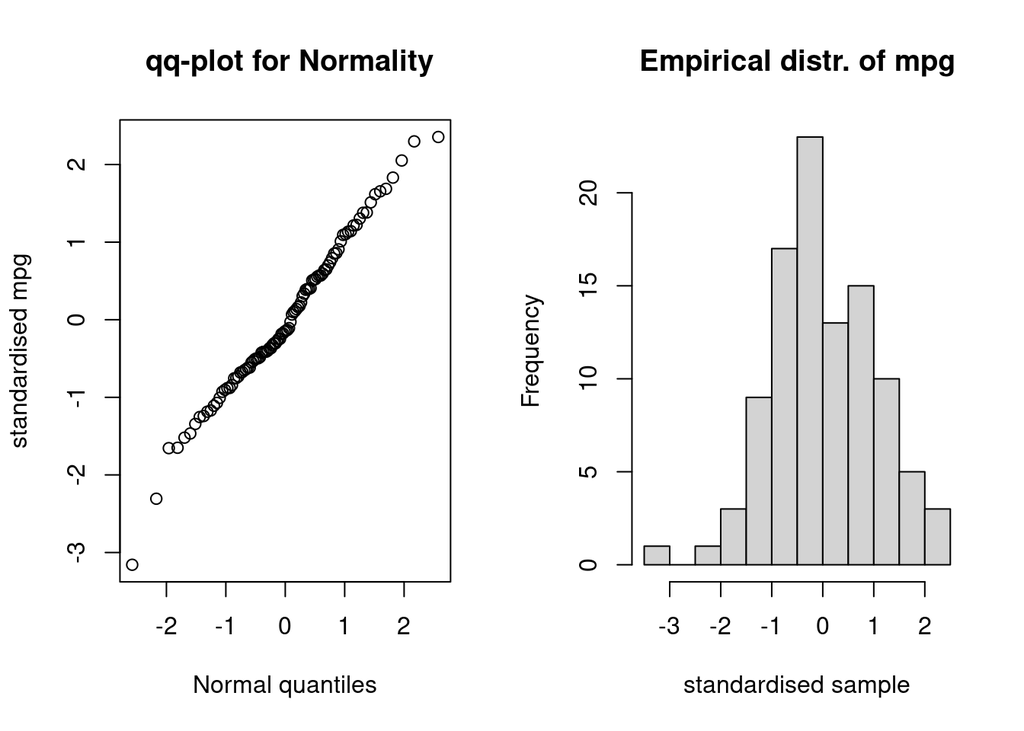

```r
# Preliminary examination
## standardise me
z_obs <- (mydata$mpg - mean(mydata$mpg)) / sd(mydata$mpg)
## plot me
par(mfrow=c(1,2))
qqnorm( z_obs,
  main = " qq-plot for Normality",
  ylab = "standardised mpg",
  xlab = "Normal quantiles"
)
hist(z_obs,
  main = "Empirical distr. of mpg",
  xlab = "standardised sample"
     )
```

# Model

We specifiy the Normal distribution with uncertain mean and variance parameters $\mu$ and $\sigma^2$ as a parametric model.

The Bayesian hierarchical model under consideration is:
$$\begin{cases}
x_{i}|\mu,\sigma^{2} & \overset{\text{iid}}{\sim}\text{N}(\mu,\sigma^{2}),\,\,\forall i=1,...,n\\
\mu|\sigma^{2} & \sim\text{N}(\mu_{0},\frac{\sigma^{2}}{\lambda_{0}})\\
\sigma^{2} & \sim\text{G}(a,b)
\end{cases}$$

for some fixed values of the hyper-parameters $\lambda_{0}$, $a$, and $b$.

Here, we just set:

- $\mu_{0}=0.0$,
- $\lambda_{0}=1.0$,
- $a_0=0.01$,
- $b_0=0.01$

# 2 Task

### … your answer

Load the library

```r
# Load rjags
library("rjags")
```

Create an input script, for rjags, containing the Bayesian hierarchical model  
1. Write the Stan program to draw a sample from the posterior distribution of the parameters $\mu$, and $\sigma^2$

```r
hierarhicalmodel <- "

  model {

  # sampling distribution

    tau_0 = lam_0 / sigma2

    for ( i in 1 : n ) {
      y[ i ] ~ dnorm( mu, tau )
    }

   # prior distribution

    mu ~ dnorm( mu_0 , tau*lam_0 )
    sigma2 = 1 / tau
    tau ~ dgamma(a_0 , b_0)

  }

"
```

Create and list with inputs for rstan

```r
a_0 <- 0.01
b_0 <- 0.01
lam_0 <- 1.0
mu_0 <- 0.0
y_obs <- mydata$mpg ;
n_obs <- length( y_obs ) ;
data.bayes <- list(n = n_obs ,     # the number of the observations
                  y = y_obs ,     # the observations
                  a_0 = a_0,
                  b_0 = b_0,
                  lam_0 = lam_0,
                  mu_0 = mu_0
                  )
```

Create an input list, for jags, containing the data and fixed parameters of the model

```r
model.smpl <- jags.model( file = textConnection(hierarhicalmodel),
                          data = data.bayes)
```

Initialize the sampler with $N_{\text{adapt}}=1000$ iterations.

- This is a warming-up procedure (used as a black-box), where the sampler is automatically tuned and calibated before it starts generatign your samples.
- Regarding $N_{\text{adapt}}=1000$, the larger the better.

```r
adapt( object = model.smpl,
       n.iter = 1000 )
```

```
## [1] TRUE
```

Generate a posterior sample of size $N=10000$.

Use

- `jags.samples{rjags}`

We need to pay attention on two flaqs:

- the `n.iter`: the total size of the total sample sequence.
- the `variable.names`: it specifies the names of the random variables correspondign to the posterior samples I am interested in generating

```r
N = 10000      # the size of the sample we ll gonna get
output = jags.samples( model= model.smpl,          # the model
                       variable.names= c("mu","sigma2"),    # names of variables to be sampled
                       n.iter = N                # size of sample
                       )
```

Check the names of the variables sampled

- use `names {base}`

```r
names(output)
```

```
## [1] "mu"     "sigma2"
```

Check the dimensions of each of the variables sampled

- use `dim {base}`

```r
dim( output$mu )
```

```
##           iteration     chain
##         1     10000         1
```

```r
dim( output$sigma2 )
```

```
##           iteration     chain
##         1     10000         1
```

```r
# the first dimension is the numbers of columns of the variable
# the second dimention is the size of the sample drawn
# the thirs dimention is the number of the sub-samples drawn (in our case it is just 1)
```

Copy the sample of each variable in a vector with a more friendly name…

```r
mu.smpl <-output$mu
sigma2.smpl <-output$sigma2
```

We plot the trace plots of the generated samples

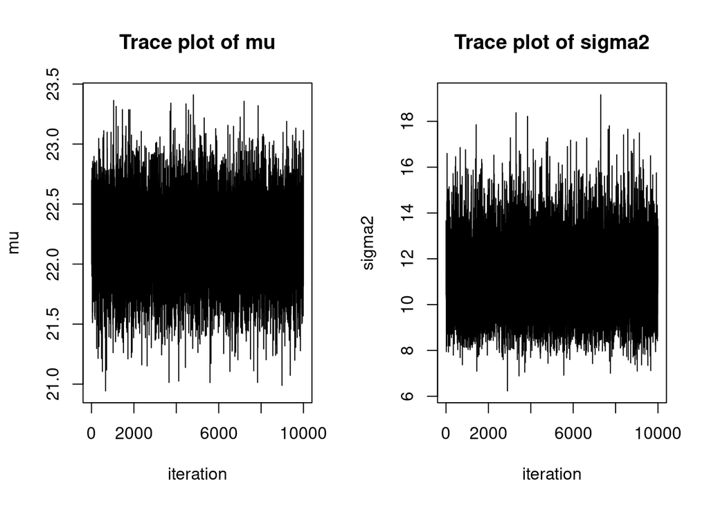

```r
# draw the trace plots

par(mfrow=c(1,2))

mu.smpl <-output$mu

plot(mu.smpl,
     type = "l",
     main = "Trace plot of mu",
     xlab = "iteration",
     ylab = "mu"
     )

sigma2.smpl <-output$sigma2

plot(sigma2.smpl,
     type = "l",
     main = "Trace plot of sigma2",
     xlab = "iteration",
     ylab = "sigma2"
     )
```

# 3 Task

Produce and plot the exact joint PDF of $(\mu,\sigma^2)$ as a 2D plot, and as a 2D contour plot

To draw 3D plots like those required to plot the exact PDF you can use the functions `persp{graphics}`, or `contour{graphics}` as `persp(x, y , z)` or `contour(x, y, z)` , where x, y are locations of grid lines at which the values in z are measured; and z is a matrix containing the values to be plotted ;

*Usage*

```
% To plot z=f(x,y) for a specific function f(.,.) at vectors x and y, then
% for known x, y vectors of length 100

z <- matrix(rep(NaN,100*100),100,100)
for (i in 1:100)
  for (j in 1:100)
    z[i,j] <-f( x[i],z[j] )

persp(x, y , z)

% or

contour(x, y, z)
```

*Hint-1*

The joint posterior distribution $(\mu,\sigma^{2})$, is:
$$\begin{cases}
\mu|x_{1:n},\sigma^2
& \sim
\text{N}(
\mu_{n},\frac{\sigma^{2}}{\lambda_{n}}
) \\
\sigma^2|x_{1:n}
& \sim
\text{IG}(
a_{n},b_{n}
)
\end{cases}$$

where
$$\begin{align*}
\mu_{n}=&
\frac{\lambda_{0}\mu_{n}+n\bar{x}}{\lambda_{0}+n} \\
\lambda_{n}=&
\lambda_{0}+n, \\
a_{n}=&
a_{0}+\frac{n}{2} \\
b_{n}=&
b_{0}+\frac{1}{2}ns^{2}+\frac{1}{2}(\lambda_{0}+n)^{-1}\lambda_{0}n(\mu_{0}-\bar{x})^{2} \\
\end{align*}$$

Hence the PDF is
$$\pi(\mu,\sigma^{2}|x_{1:n}) =
\text{N}(\mu|\mu_{n},\frac{\sigma^{2}}{\lambda_{n}})
\text{IG}(\sigma^{2}|a_{n},b_{n})$$

*Hint:*

Additional functions for PDFs and CDFs are given

```r
# Inverse Gamma PDF
invgamma_pdf <- function (x,a,b) {
  return(exp(a*log(b)-lgamma(a)-(a+1)*log(x)-b/x))
}
# Inverse Gamma CDF
invgamma_cdf <- function (x,a,b) {
  return(1.0-pgamma(1.0/x,shape=a,scale=1.0/b) )
}
```

### … your answer

```r
library(gplots)
```

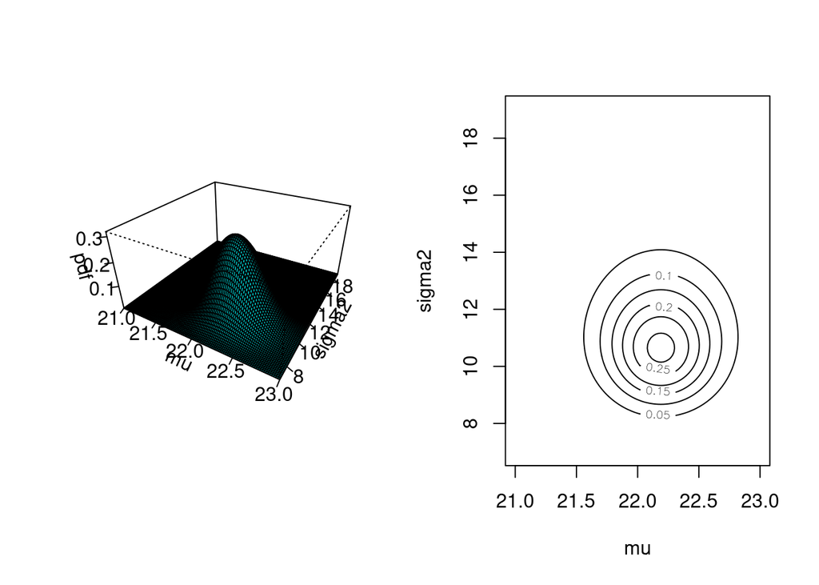

```r
par(mfrow=c(1,2))

# EXACT

## compute the osterior parameters
a_n <- a_0 +0.5*n_obs
b_n <- b_0 +0.5*n_obs*var(y_obs) +0.5*lam_0*n_obs*(mu_0-mean(y_obs))^2/(lam_0+n_obs)
lam_n <- lam_0 + n_obs
mu_n <- (lam_0*mu_0+n_obs*mean(y_obs)) / (lam_0+n_obs)

## plot
xmin = 21
xmax = 23
x_plot <- seq( from = xmin,
               to = xmax,
               length.out = 100)
ymin = 7
ymax = 19
y_plot <-seq( from = ymin,
               to = ymax,
               length.out = 100)
z_plot <- matrix(rep(NaN,100*100),100,100)
for (i in 1:100)
  for (j in 1:100)
    z_plot[i,j] <- dnorm( x_plot[i], mu_n, sqrt(y_plot[j]/lam_n) ) * invgamma_pdf(y_plot[j], a_n, b_n) ;

## plot
persp(x_plot, y_plot,  z_plot,
      ticktype="detailed", theta=30, phi=30,
      expand=0.5, shade=0.5, col="cyan", ltheta=-30,
      xlab = 'mu',
      ylab='sigma2',
      zlab='pdf')
## plot
contour(x_plot, y_plot,  z_plot,
      xlab = 'mu',
      ylab='sigma2')
```

# 4 Task

Produce and plot the MC approximation of the joint PDF of $(\mu,\sigma^2)$, as a 2D histogram, and as a 2D contour plot.

To draw histograms of 2D samples like required by the MC approximation of the PDF you can use the functions `hist2d{gplots}` and `persp{graphics}`, or `contour{graphics}` as:

```
% known vectors x and y of length 100 having the 2D samples:

h2d <- hist2d(x,y,nbins=c(20,30),show=FALSE)

persp( h2d$x, h2d$y, h2d$counts, ticktype="detailed", theta=30, phi=30,expand=0.5, shade=0.5, col="cyan", ltheta=-30)

contour( h2d$x, h2d$y, h2d$counts, ticktype="detailed", theta=30, phi=30,expand=0.5, shade=0.5, col="cyan", ltheta=-30)
```

### … your answer

```r
library(gplots)
```

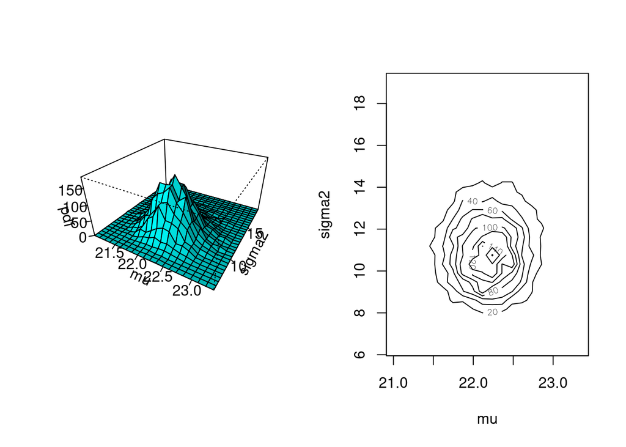

```r
mu.smpl <-output$mu
sigma2.smpl <-output$sigma2

# MC APPROXIMATION

par(mfrow=c(1,2))

## extract the sample

h2d <-  hist2d(mu.smpl,
               sigma2.smpl,
               nbins=c(20,30),
               show=FALSE)

## plot
persp(h2d$x, h2d$y, h2d$counts,
      ticktype="detailed", theta=30, phi=30,
      expand=0.5, shade=0.5, col="cyan", ltheta=-30,
      xlab = 'mu',
      ylab='sigma2',
      zlab='pdf')

## plot
contour(h2d$x, h2d$y, h2d$counts,
      xlab = 'mu',
      ylab='sigma2')
```

# 5 Task

Produce and plot the Exact marginal PDF of $\mu$.

Produce and plotthe MC approximation of the marginal PDF of $\mu$.

You can use the functions `hist {graphics}` and `lines {graphics}` or `plots {graphics}`

*Hint*

The marginal distribution of $\mu$, is:
$$\mu|x_{1:n}\sim\text{St}_{k}(\mu_{n},\frac{b_{n}}{\lambda_{n}a_{n}},2a_{n})$$

where
$$\begin{align*}
\mu_{n}=&
\frac{\lambda_{0}\mu_{n}+n\bar{x}}{\lambda_{0}+n} \\
\lambda_{n}=&
\lambda_{0}+n, \\
a_{n}=&
a_{0}+\frac{n}{2} \\
b_{n}=&
b_{0}+\frac{1}{2}ns^{2}+\frac{1}{2}(\lambda_{0}+n)^{-1}\lambda_{0}n(\mu_{0}-\bar{x})^{2} \\
\end{align*}$$

*Hint:*

Additional PDFs and CDFs are given

```r
# Student T PDF
studentT_pdf <- function(x,m,s,v) {
  return(dt((x-m)/sqrt(s),df=v)/sqrt(s))
}
# Student T CDF
studentT_cdf <- function(x,m,s,v) {
  return(pt((x-m)/sqrt(s),df=v))
}
```

### … your answer

For the marginal posterior PDF of $\mu$

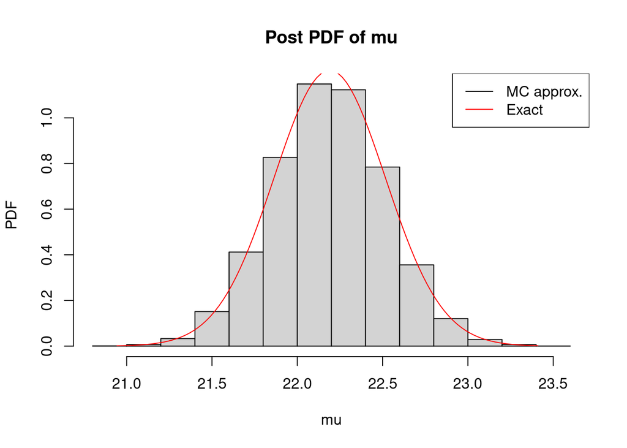

```r
# Draw the histogram as the MC approximate of the PDF

mu.smpl <-output$mu

z <- mu.smpl
hist(z,
     probability = TRUE,
     main = "Post PDF of mu",
     xlab = "mu",
     ylab = "PDF")


# Draw the exact PDF

## Posterior parameters
a_n <- a_0 +0.5*n_obs
b_n <- b_0 +0.5*n_obs*var(y_obs) +0.5*lam_0*n_obs*(mu_0-mean(y_obs))^2/(lam_0+n_obs)
lam_n <- lam_0 + n_obs
mu_n <- (lam_0*mu_0+n_obs*mean(y_obs)) / (lam_0+n_obs)

x_plot <- seq( from = min(z), to = max(z), length.out = 100)
y_plot <- studentT_pdf(x_plot , mu_n , b_n/(a_n*lam_n), 2*a_n)
lines(x_plot,
      y_plot,
      type = 'l',
      col = 'red')
legend("topright",
       legend=c("MC approx.", "Exact"),
       lty = c(1,1),
       col=c("black", "red"))
```

For the marginal posterior CDF of $\mu$

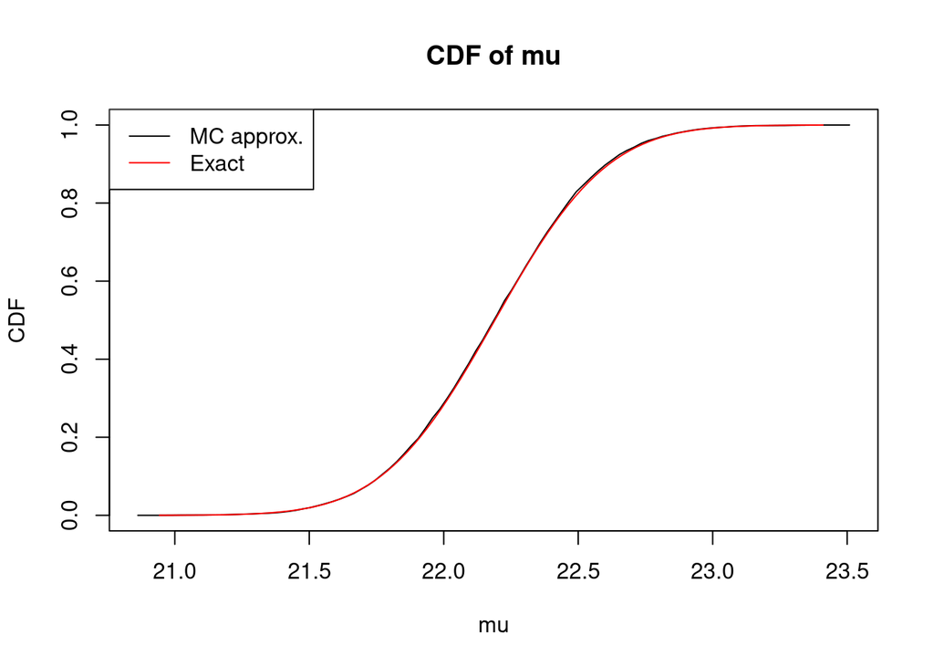

```r
# Draw the histogram as the MC approximate of the CDF

## extract the sample, and copy it to smple
mu.smpl <-output$mu

z <- mu.smpl
x_plot <- seq( from = mean(z)-4*sd(z), to = mean(z)+4*sd(z), length.out = 100)
y_plot <- rep(NaN, 100)
for (i in 1:100) y_plot[i] <- mean(z<=x_plot[i])
plot(x_plot,
     y_plot,
     type = "l",
     main = "CDF of mu",
     xlab = "mu",
     ylab = "CDF")

#  Draw the exact CDF

## Posterior parameters
a_n <- a_0 +0.5*n_obs
b_n <- b_0 +0.5*n_obs*var(y_obs) +0.5*lam_0*n_obs*(mu_0-mean(y_obs))^2/(lam_0+n_obs)
lam_n <- lam_0 + n_obs
mu_n <- (lam_0*mu_0+n_obs*mean(y_obs)) / (lam_0+n_obs)
x_plot <- seq( from = min(z), to = max(z), length.out = 100)
y_plot <- studentT_cdf(x_plot , mu_n , b_n/(a_n*lam_n), 2*a_n)
lines(x_plot,
      y_plot,
      type = 'l',
      col = 'red')

legend("topleft",
       legend=c("MC approx.", "Exact"),
       lty = c(1,1),
       col=c("black", "red"))
```

# 6 Task

Produce and plot the Exact marginal PDF of $\sigma^2$.

Produce and plot the MC approximation of the marginal PDF of $\sigma^2$.

You can use the functions `hist {graphics}` and `lines {graphics}` or `plot {graphics}`

*Hint*

The marginal distributions of $\sigma^{2}$, as:
$$\sigma^2|x_{1:n}
\sim
\text{IG}(\sigma^{2}|a_{n},b_{n})$$

where
$$\begin{align*}
\mu_{n}=&
\frac{\lambda_{0}\mu_{n}+n\bar{x}}{\lambda_{0}+n} \\
\lambda_{n}=&
\lambda_{0}+n, \\
a_{n}=&
a_{0}+\frac{n}{2} \\
b_{n}=&
b_{0}+\frac{1}{2}ns^{2}+\frac{1}{2}(\lambda_{0}+n)^{-1}\lambda_{0}n(\mu_{0}-\bar{x})^{2} \\
\end{align*}$$

*Hint:*

Additional PDFs and CDFs are given

```r
# Inverse Gamma PDF
invgamma_pdf <- function (x,a,b) {
  return(exp(a*log(b)-lgamma(a)-(a+1)*log(x)-b/x))
}
# Inverse Gamma CDF
invgamma_cdf <- function (x,a,b) {
  return(1.0-pgamma(1.0/x,shape=a,scale=1.0/b) )
}
```

### … your answer

For the marginal posterior PDF of $\sigma^2$

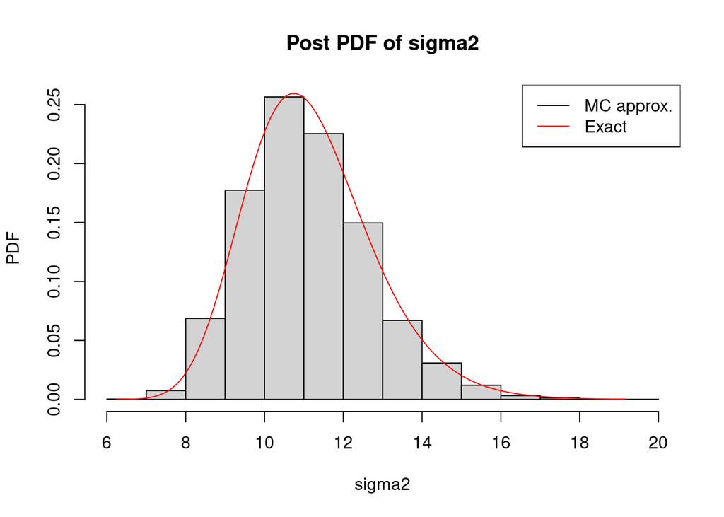

```r
# Draw the histogram as the MC approximate of the PDF

## extract the sample, and copy it to smple
sigma2.smpl <-output$sigma2

z <- sigma2.smpl
hist(z,
     probability = TRUE,
     main = "Post PDF of sigma2",
     xlab = "sigma2",
     ylab = "PDF")

# Draw the exact PDF

## Posterior parameters
a_n <- a_0 +0.5*n_obs
b_n <- b_0 +0.5*n_obs*var(y_obs) +0.5*lam_0*n_obs*(mu_0-mean(y_obs))^2/(lam_0+n_obs)
lam_n <- lam_0 + n_obs
mu_n <- (lam_0*mu_0+n_obs*mean(y_obs)) / (lam_0+n_obs)

x_plot <- seq( from = min(z), to = max(z), length.out = 100)
y_plot <- invgamma_pdf(x_plot , a_n, b_n)
lines(x_plot,
      y_plot,
      type = 'l',
      col = 'red')
legend("topright",
       legend=c("MC approx.", "Exact"),
       lty = c(1,1),
       col=c("black", "red"))
```

For the marginal posterior CDF of $\sigma^2$

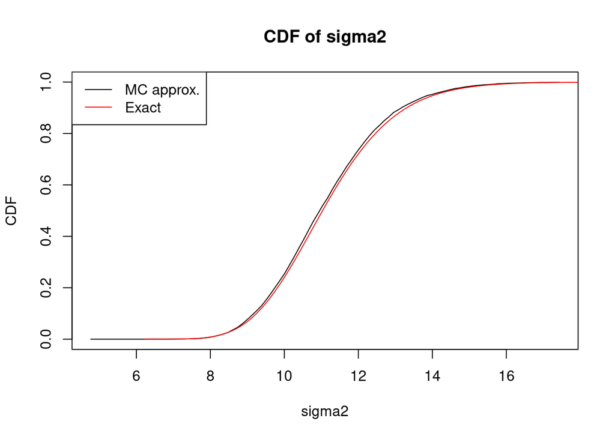

```r
# Draw the histogram as the MC approximate of the CDF

## extract the sample, and copy it to smple
sigma2.smpl <-output$sigma2

z <- sigma2.smpl
x_plot <- seq( from = mean(z)-4*sd(z), to = mean(z)+4*sd(z), length.out = 100)
y_plot <- rep(NaN, 100)
for (i in 1:100) y_plot[i] <- mean(z<=x_plot[i])
plot(x_plot,
     y_plot,
     type = "l",
     main = "CDF of sigma2",
     xlab = "sigma2",
     ylab = "CDF")

# Draw the exact CDF

## Posterior parameters
a_n <- a_0 +0.5*n_obs
b_n <- b_0 +0.5*n_obs*var(y_obs) +0.5*lam_0*n_obs*(mu_0-mean(y_obs))^2/(lam_0+n_obs)
lam_n <- lam_0 + n_obs
mu_n <- (lam_0*mu_0+n_obs*mean(y_obs)) / (lam_0+n_obs)

x_plot <- seq( from = min(z), to = max(z), length.out = 100)
y_plot <- invgamma_cdf(x_plot , a_n, b_n)
lines(x_plot,
      y_plot,
      type = 'l',
      col = 'red')
legend("topleft",
       legend=c("MC approx.", "Exact"),
       lty = c(1,1),
       col=c("black", "red"))
```

# 7 Task

- Compute the MC approximate of the posterior mean of $\mu$, and $\sigma^2$:
  $$\text{E}_\pi (\mu|y_{1:n})
  \approx
  \frac{1}{N}\sum_{j=1}^{N}\mu^{(j)}$$
  and
  $$\text{E}_\pi (\sigma^2|y_{1:n})
  \approx
  \frac{1}{N}\sum_{j=1}^{N} \left(\sigma^{(j)}\right)^2$$
- Compute their exact values which are
  $$\text{E}_\pi (\mu|y_{1:n}) = \mu_n$$
  and
  $$\text{E}_\pi (\sigma^2|y_{1:n}) = \frac{b_n}{a_n-1}$$

### … your answer

The Monte Carlo approximation for $\text{E}_\pi (\mu|y_{1:n})$ is

```r
mu.smpl <-output$mu
mc.approx <- mean(mu.smpl)
mc.approx
```

```
## [1] 22.18566
```

The exact value for $\text{E}_\pi (\mu|y_{1:n})=\mu_n$ is

```r
# Posterior parameters
mu_n <- (lam_0*mu_0+n_obs*mean(y_obs)) / (lam_0+n_obs)
mu_n
```

```
## [1] 22.19009
```

The Monte Carlo approximation for $\text{E}_\pi (\sigma^2|y_{1:n})$ is

```r
sigma2.smpl <-output$sigma2
mc.approx <- mean(sigma2.smpl)
mc.approx
```

```
## [1] 11.1008
```

The exact value for $\text{E}_\pi (\sigma^2|y_{1:n})= \frac{b_n}{a_n-1}$ is

```r
# Posterior parameters
a_n <- a_0 +0.5*n_obs
b_n <- b_0 +0.5*n_obs*var(y_obs) +0.5*lam_0*n_obs*(mu_0-mean(y_obs))^2/(lam_0+n_obs)
exct <- b_n/(a_n-1)
exct
```

```
## [1] 11.18335
```

# 8 Task

- Compute the MC approximate of the posterior prabability that the mean fuel efficiency (in mpg) of car is greater or equal to $22.5$ mpg.
  $$\begin{align}
  \text{Pr}_\pi (\mu\ge 22.5|y_{1:n})
  &=
  1-\text{Pr}_\pi (\mu< 22.5|y_{1:n}) \\
  &=
  1-\text{E}_\pi (\text{1}(\mu< 22.5)|y_{1:n}) \\
  &\approx
  1-\frac{1}{N}\sum_{j=1}^{N}\text{1}(\mu^{(j)} < 22.5)
  \end{align}$$
- Compute the exact value which is
  $$\begin{align}
  \text{Pr}_\pi (\mu\ge 22.5|y_{1:n}) =& 1-\text{Pr}_{\text{St}_{k}(\mu_{n},\frac{b_{n}}{\lambda_{n}a_{n}},2a_{n})}(\mu\le 22.5|y_{1:n}) \\
  =&
  1-\int_{-\infty}^{22.5}\text{St}_{k}(\mu|\mu_{n},\frac{b_{n}}{\lambda_{n}a_{n}},2a_{n})\text{d}\mu
  \end{align}$$

*Hint*

Functions for the PDFs and CDF are given

```r
# Student T PDF
studentT_pdf <- function(x,m,s,v) {
  return(dt((x-m)/sqrt(s),df=v)/sqrt(s))
}
# Student T CDF
studentT_cdf <- function(x,m,s,v) {
  return(pt((x-m)/sqrt(s),df=v))
}
```

### … your answer

The MC approximate is

```r
## extract the sample, and copy it to smple
mu.smpl <-output$mu
Pr.mu.mc <- mean( mu.smpl>=22.5 )
Pr.mu.mc
```

```
## [1] 0.1659
```

and its exact value is …

```r
## Posterior parameters
a_n <- a_0 +0.5*n_obs
b_n <- b_0 +0.5*n_obs*var(y_obs) +0.5*lam_0*n_obs*(mu_0-mean(y_obs))^2/(lam_0+n_obs)
lam_n <- lam_0 + n_obs
mu_n <- (lam_0*mu_0+n_obs*mean(y_obs)) / (lam_0+n_obs)
## The Exact value is
Pr.mu.ex <- 1-studentT_cdf(22.5, mu_n, b_n/(lam_n*a_n), 2*a_n)
Pr.mu.ex
```

```
## [1] 0.1745368
```

The MC approximation is good!

# 9 Task

Compute the exact $95\%$ equal tail posterior credible interval of $\mu$.

*Hint*

The marginal distribution of $\mu$, is:
$$\mu|x_{1:n}\sim\text{St}_{k}(\mu_{n},\frac{b_{n}}{\lambda_{n}a_{n}},2a_{n})$$

where
$$\begin{align*}
\mu_{n}=&
\frac{\lambda_{0}\mu_{n}+n\bar{x}}{\lambda_{0}+n} \\
\lambda_{n}=&
\lambda_{0}+n, \\
a_{n}=&
a_{0}+\frac{n}{2} \\
b_{n}=&
b_{0}+\frac{1}{2}ns^{2}+\frac{1}{2}(\lambda_{0}+n)^{-1}\lambda_{0}n(\mu_{0}-\bar{x})^{2} \\
\end{align*}$$

Compute the MC approximation of the $95\%$ equal tail posterior credible interval of $\mu$.

*Hint:*

Additional PDFs and CDFs are given

```r
# Student T INVERSE CDF
studentT_inv <- function(prob,m,s,v) {
  q = qt( prob, df=v )
  return( m+sqrt(s*v/(v-2))*q )
}
```

### … your answer

The exact CI is

```r
# Posterior parameters
a_n <- a_0 +0.5*n_obs
b_n <- b_0 +0.5*n_obs*var(y_obs) +0.5*lam_0*n_obs*(mu_0-mean(y_obs))^2/(lam_0+n_obs)
lam_n <- lam_0 + n_obs
mu_n <- (lam_0*mu_0+n_obs*mean(y_obs)) / (lam_0+n_obs)
# CI
studentT_inv(c(0.025,0.975), mu_n , b_n/lam_n/a_n, 2*a_n )
```

```
## [1] 21.52991 22.85026
```

The MC approximation of the CI is

```r
# extract the sample, and copy it to smple
mu.smpl <-output$mu
quantile(mu.smpl, probs =c(0.025,0.975))
```

```
##     2.5%    97.5%
## 21.53252 22.83926
```

# 10 Task

*Hint*

The marginal distribution of $\mu$, is:
$$\mu|x_{1:n}\sim\text{St}_{k}(\mu_{n},\frac{b_{n}}{\lambda_{n}a_{n}},2a_{n})$$

where
$$\begin{align*}
\mu_{n}=&
\frac{\lambda_{0}\mu_{n}+n\bar{x}}{\lambda_{0}+n} \\
\lambda_{n}=&
\lambda_{0}+n, \\
a_{n}=&
a_{0}+\frac{n}{2} \\
b_{n}=&
b_{0}+\frac{1}{2}ns^{2}+\frac{1}{2}(\lambda_{0}+n)^{-1}\lambda_{0}n(\mu_{0}-\bar{x})^{2} \\
\end{align*}$$

*Hint:*

Additional PDFs and CDFs are given

```r
# Student T INVERSE CDF
invgamma_inv <- function (prob, a, b){
    return(qgamma(1 - prob, a, b)^(-1))
}
```

### … your answer

The exact CI is

```r
# Posterior parameters
a_n <- a_0 +0.5*n_obs
b_n <- b_0 +0.5*n_obs*var(y_obs) +0.5*lam_0*n_obs*(mu_0-mean(y_obs))^2/(lam_0+n_obs)
# CI
invgamma_inv(c(0.025,0.975), a_n , b_n )
```

```
## [1]  8.459318 14.765687
```

The MC approximation of the CI is

```r
# extract the sample, and copy it to smple
sigma2.smpl <-output$sigma2
quantile(sigma2.smpl, probs =c(0.025,0.975))
```

```
##      2.5%     97.5%
##  8.449365 14.613041
```